# Gold Standard - Normalization Assessment

# Datasets

General characteristics of each dataset are depicted in the following table:

| Number | ID | Repository | Acquisition | MS instrument | Analysis Software | Specie | Tissue | N groups | Group names | Sample size | Publication (DOI) | More docs | Comments |
| --- | --- | --- | --- | --- | --- | --- | --- | --- | --- | --- | --- | --- | --- |
| 1 | PXD055210 | PRIDE | DDA | Q Exactive HF-X | MaxQuant | Mus musculus | embrionic fibroblast | 2 | Edu;DMSO | 10 | DOI: 10.1128/JVI.00790-24 | XLSX: Supplementary table | 2 conditions assessed: pulse and pulseChase |
| 2 | PXD058699 | PRIDE | DDA | Q Exactive HF-X | MaxQuant | Homo sapiens | Jurkat cell; T cell | 4 | (gap);L;M;H | 20 | DOI: 10.1016/J.CCELL.2025.02.008 |  |  |
| 3 | PXD025933 | PRIDE | DDA | Q Exactive Plus | MaxQuant | Homo sapiens | Neural retina; Pluripotencial stem cells Brain | 3 |  | 9 | DOI: 10.1016/j.stemcr.2022.04.003 |  |  |
| 4 | PXD031710 | PRIDE | DDA | Orbitrap Fusion | MaxQuant | Mus musculus |  | 6 | 1;2;3;4;5;6 | 18 | DOI: 10.1038/s41467-022-29486-z | XLSX: Supplementary table (sheet sf6g) |  |
| 5 | PXD066495 | PRIDE | DDA | Orbitrap Ascend | MaxQuant | Homo sapiens | Cell culture | 2 | SCR;sgALAS1 | 16 | DOI: 10.1016/J.CELL.2025.10.028 | XLSX: supplementary sample legend |  |
| 6 | PXD065898 | PRIDE | DDA | Orbitrap Exploris 480 | MaxQuant | Homo sapiens | Cell culture | 4 | Nutlin;DMSO | 16 | Pending | XLSX: sample information |  |
| 7 | PXD064630 | PRIDE | DDA | Q Exactive HF | MaxQuant | Mus musculus | Bone marrow; macrophage | 2 | wt;ko | 24 | DOI: 10.1016/j.jbc.2025.110916 | TXT: sample legend |  |
| 8 | PXD043324 | PRIDE | DDA | Q Exactive Plus | FragPipe | Homo sapiens | Serum | 3 | CTR;CZS-;CZS+ | 29 | DOI: 10.1021/ACS.JPROTEOME.3C00677 | TXT: sample legend | spectral count todo? |
| 9 | PXD058626 | PRIDE | DDA | timsTOF SCP | FragPipe | Homo sapiens | Lung tissue | 2 | Control;IPF | 24 | DOI: 10.1172/JCI.INSIGHT.189636 |  | 2 subtissues assessed: airway and alveoli |
| 10 | PXD029547 | PRIDE | DDA | timsTOF Pro | FragPipe | Homo sapiens | Blood plasma | 2 | acute;recovery | 33 | DOI: 10.1371/journal.ppat.1010176 | CSV: codex and zip with all results from fragpipe |  |

[output cut: 40 more lines]

# Assessment

## PXD022561

### item0

$item0

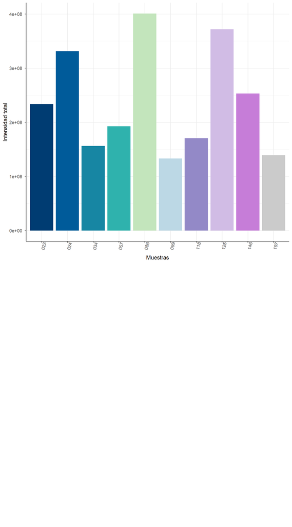

### item1

$item1

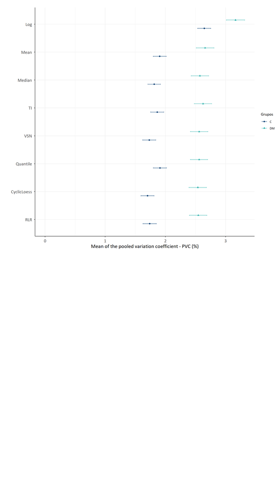

### item2

$item2

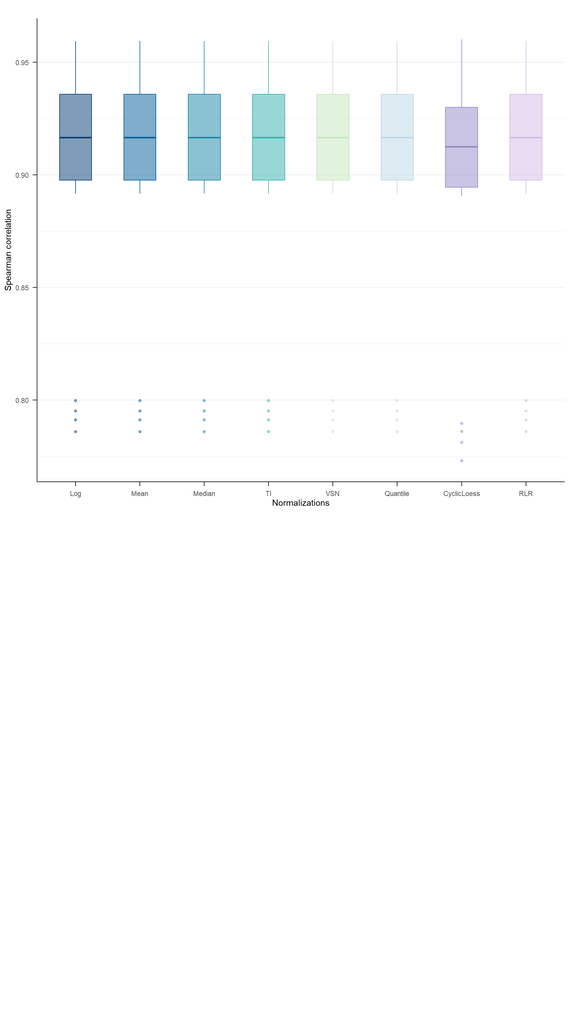

### item3

$item3

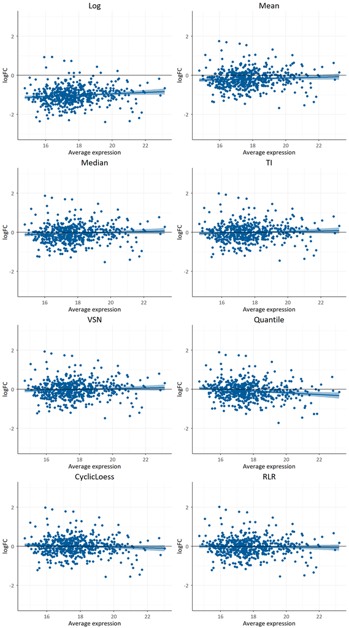

### item4

$item4

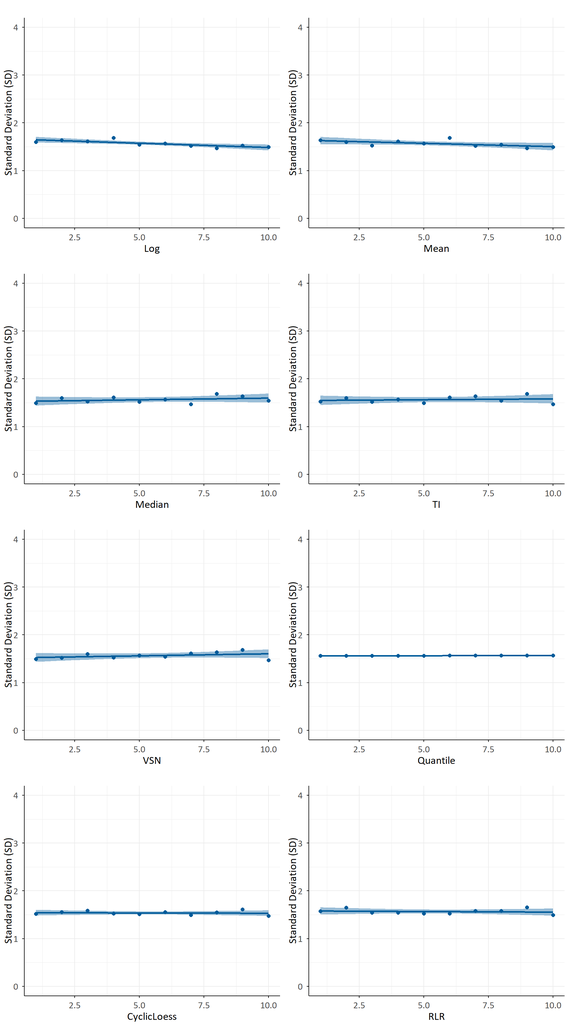

### item5

$item5

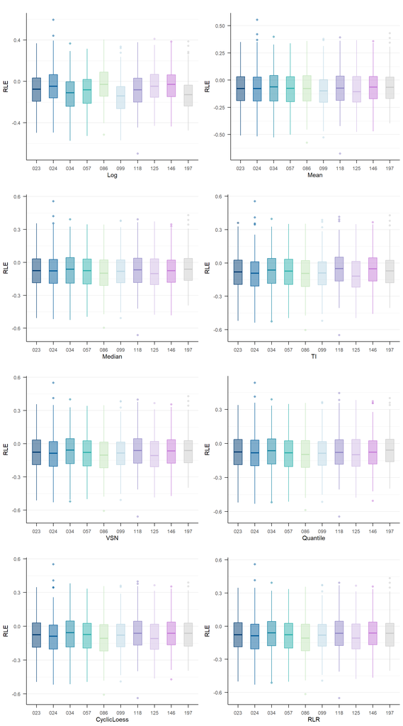

### item6

$item6

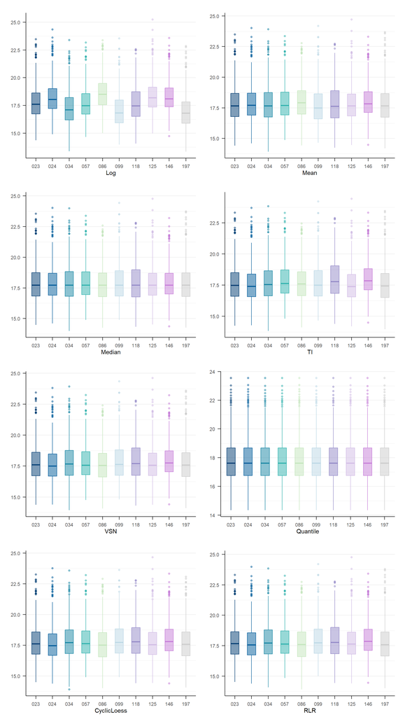

## PXD025933

### item0

$item0

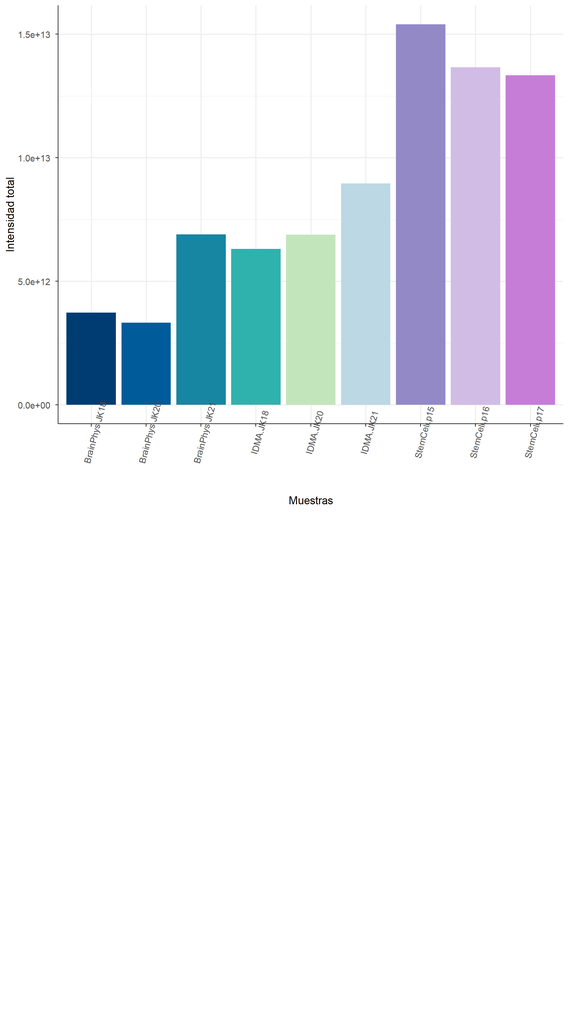

### item1

$item1

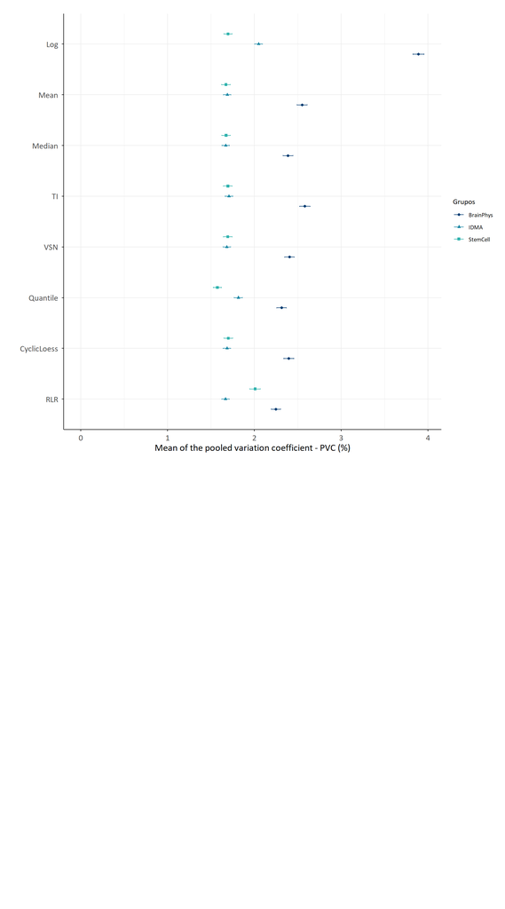

### item2

$item2

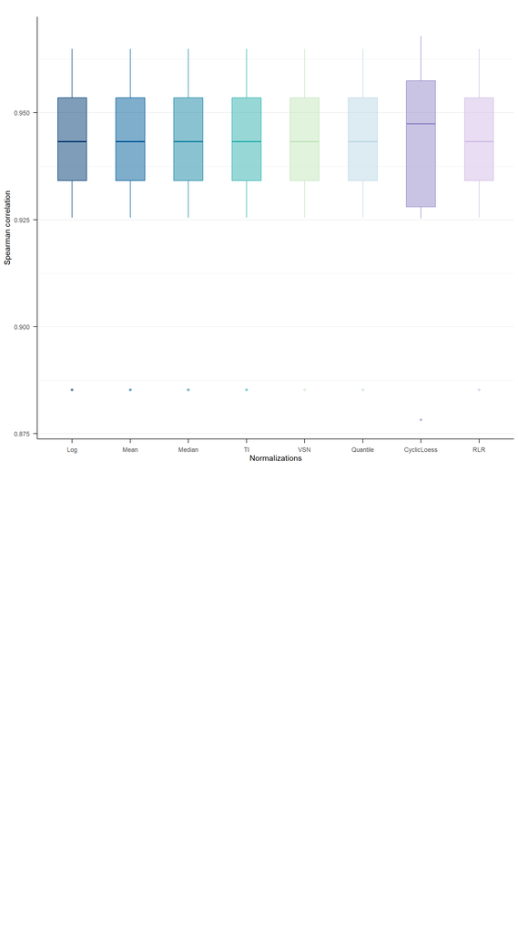

### item3

$item3

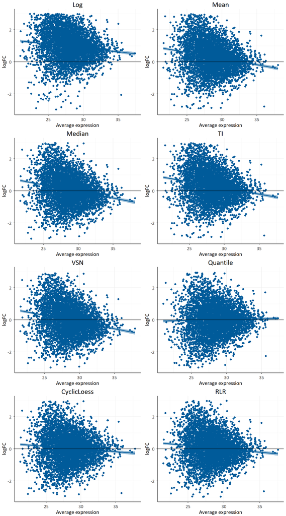

### item4

$item4

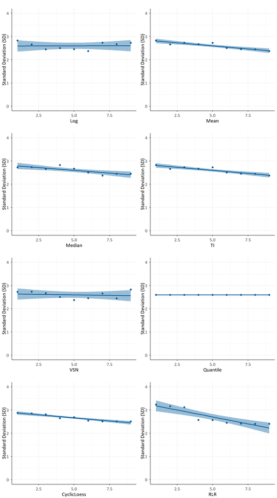

### item5

$item5

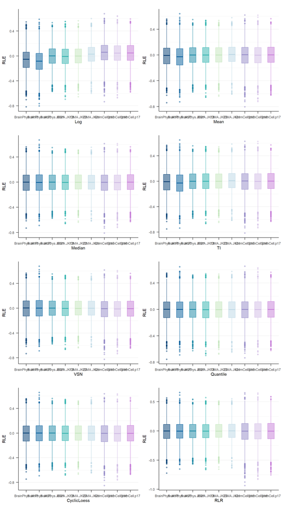

### item6

$item6

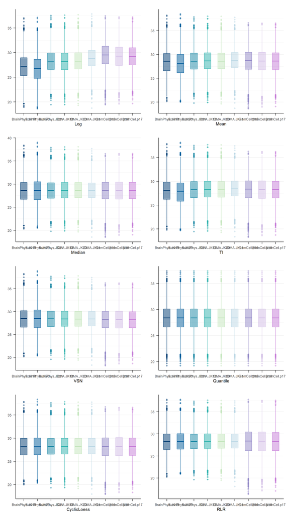

## PXD031710

### item0

$item0

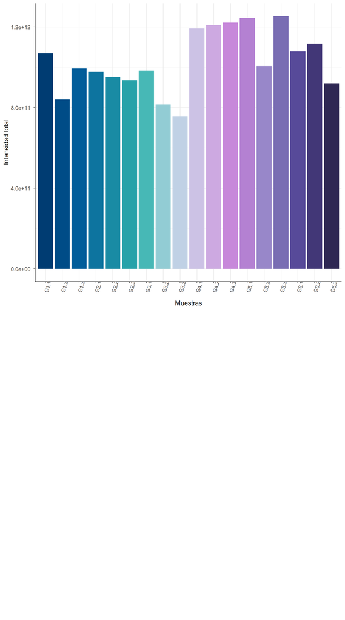

### item1

$item1

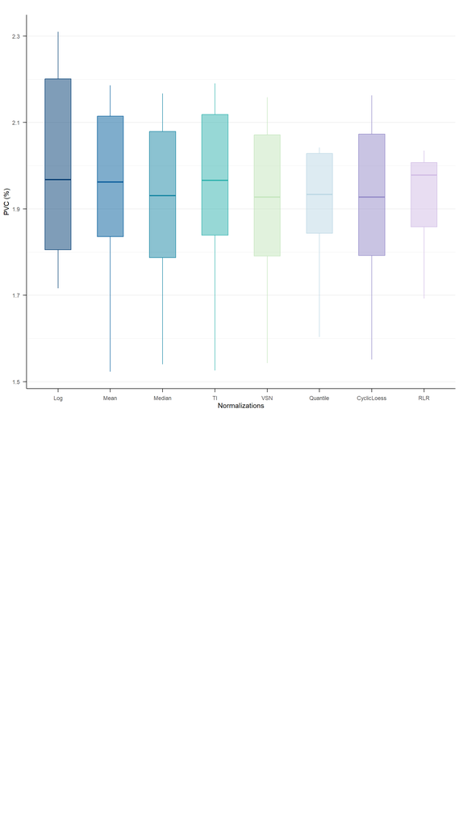

### item2

$item2

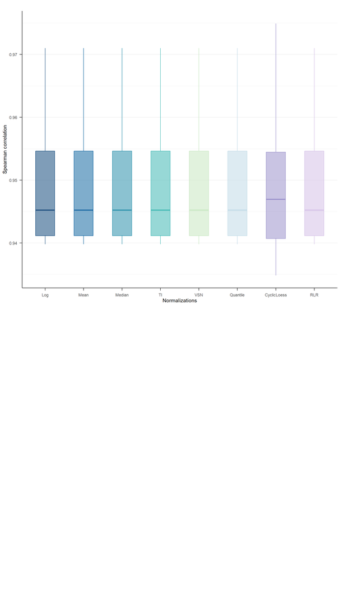

### item3

$item3

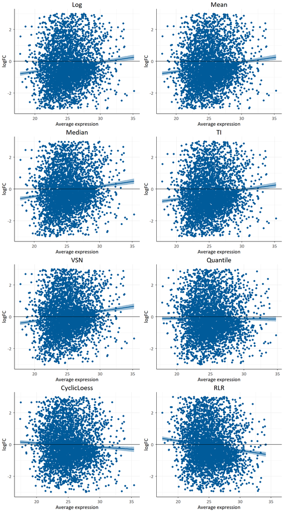

### item4

$item4

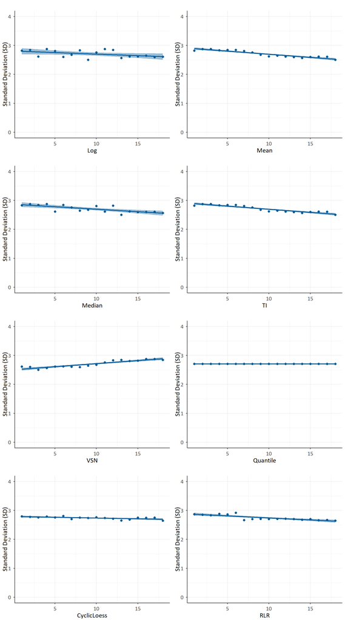

### item5

$item5

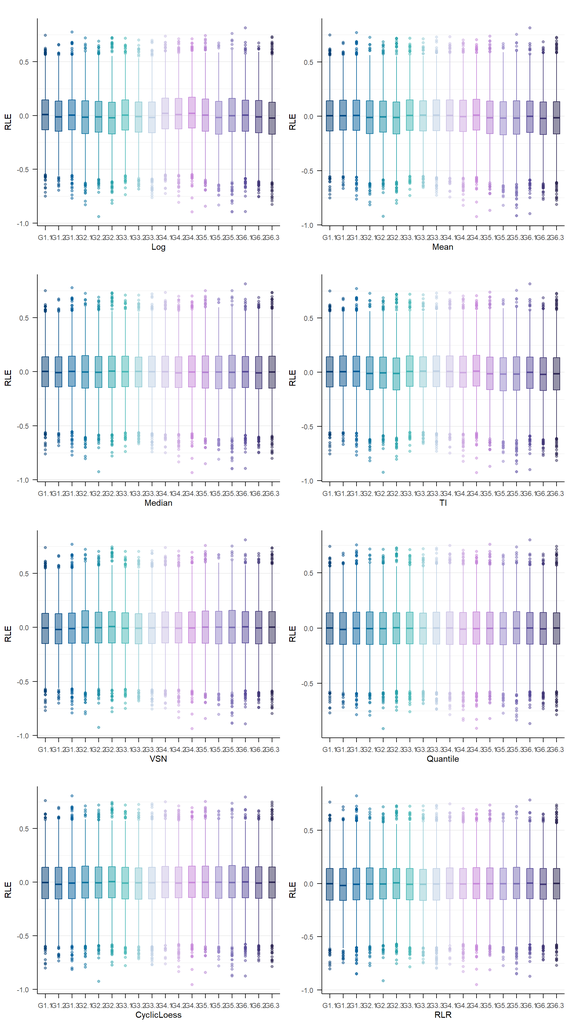

### item6

$item6

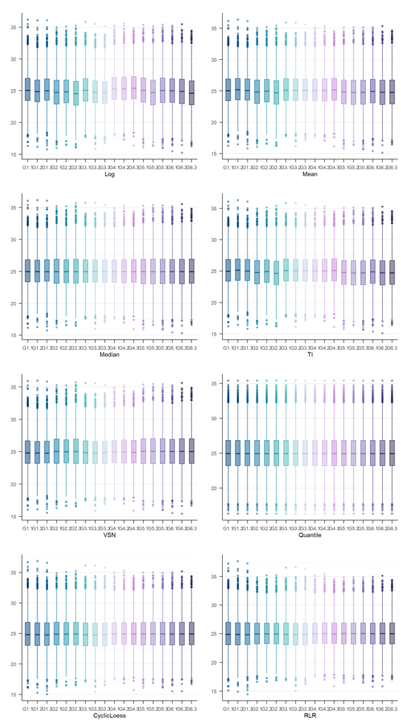

## PXD033101

### item0

$item0

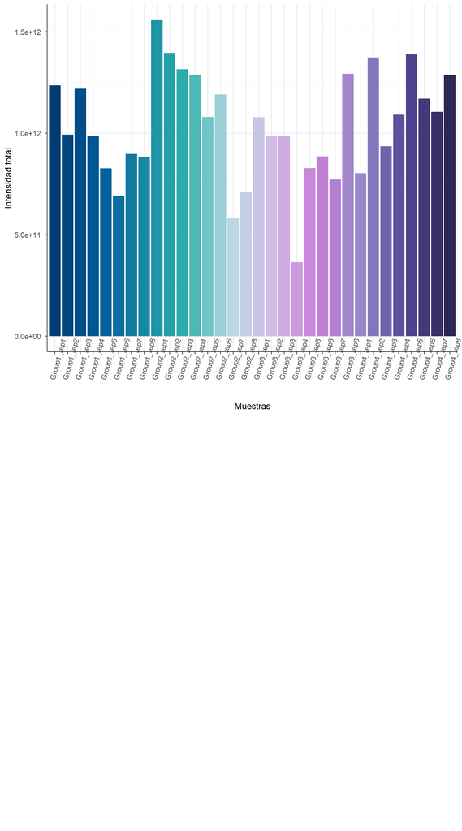

### item1

$item1

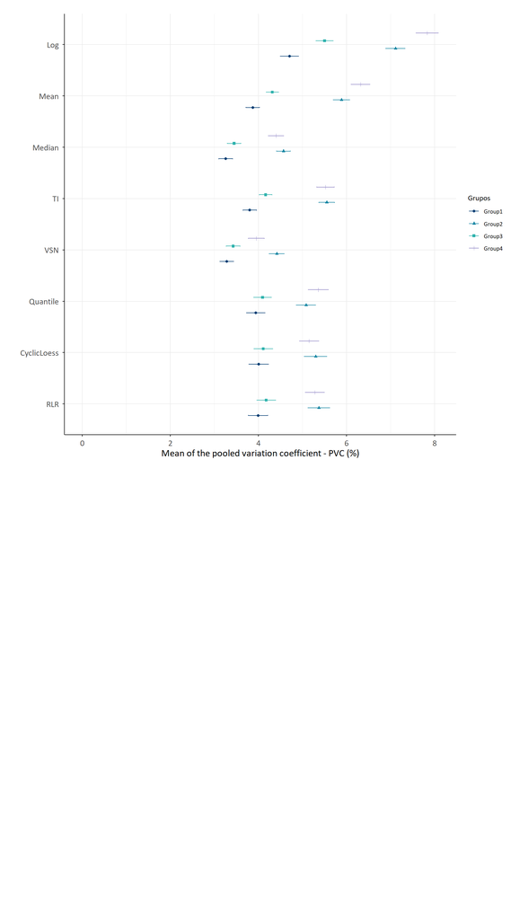

### item2

$item2

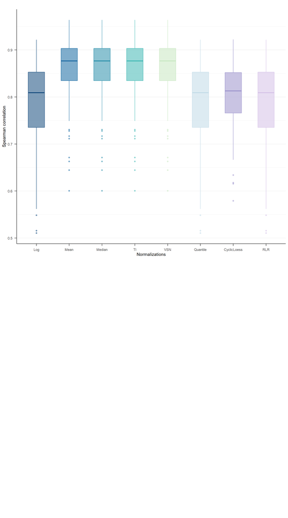

### item3

$item3

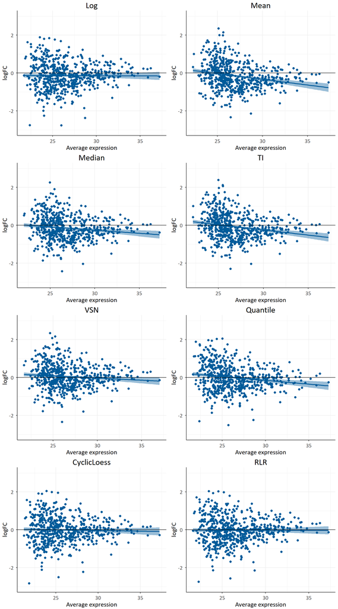

### item4

$item4

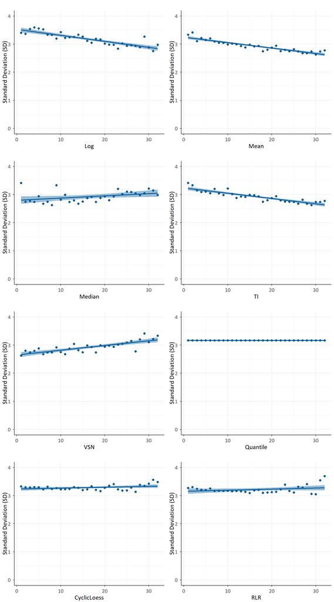

### item5

$item5

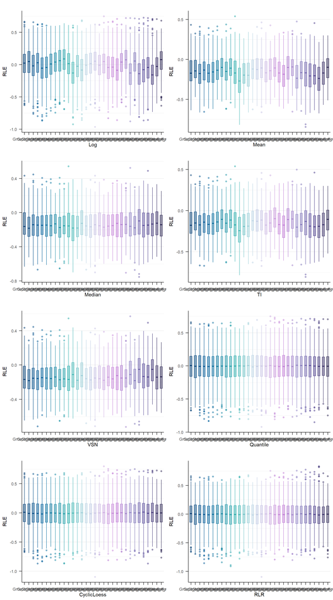

### item6

$item6

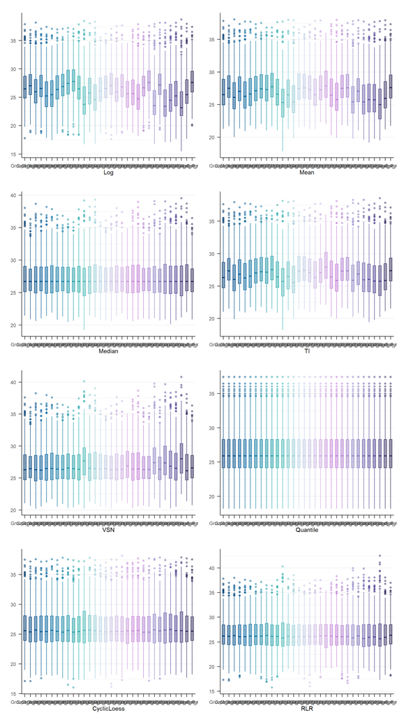

## PXD055210

### item0

$item0

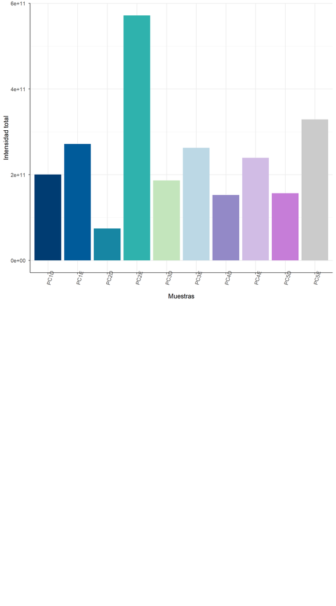

### item1

$item1

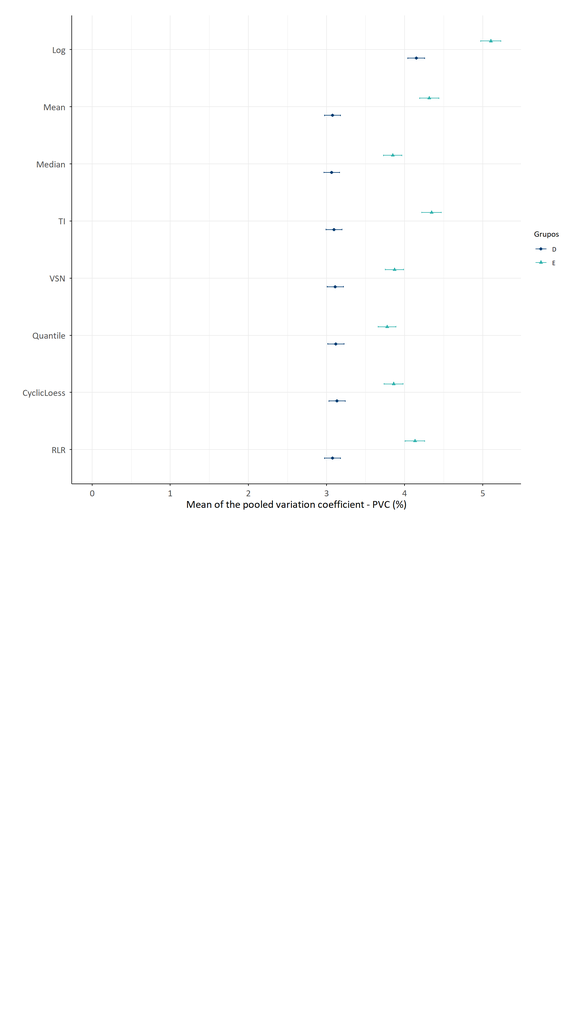

### item2

$item2

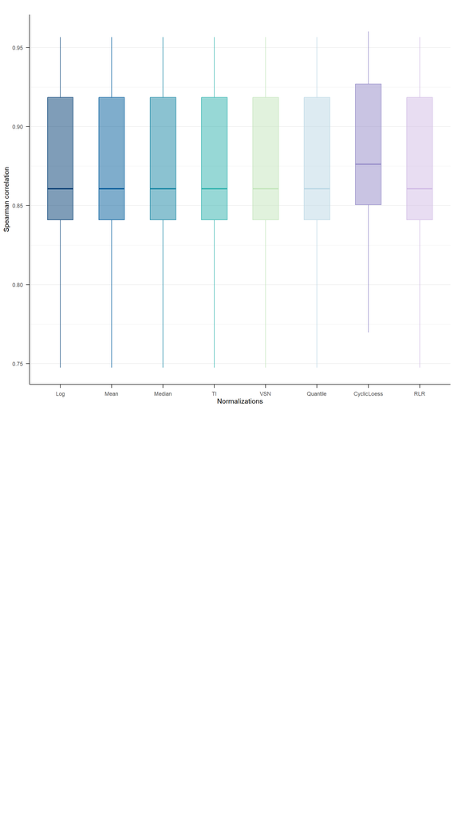